# ANALISIS_INVENTARIO

```python
import pandas as pd
import matplotlib.pyplot as plt
```

```python
df = pd.read_excel("datos/dataset_productos_categorias.xlsx")

print("Datos cargados correctamente")
print(f"Filas: {df.shape[0]}")
print(f"Columnas: {df.shape[1]}")

df.head()
```

```
Datos cargados correctamente
Filas: 1000
Columnas: 3
```

|  | ID | Producto | Categoría |
| --- | --- | --- | --- |
| 0 | 1 | Impresora | Impresión |
| 1 | 2 | Mouse | Perifericos |
| 2 | 3 | Laptop | Computadores |
| 3 | 4 | Cámara Web | Perifericos |
| 4 | 5 | Teclado | Perifericos |

```python
print("Información general del dataset:")
df.info()

print("\nColumnas del dataset:")
print(df.columns.tolist())

print("\nValores nulos por columna:")
print(df.isnull().sum())
```

```
Información general del dataset:
<class 'pandas.core.frame.DataFrame'>
RangeIndex: 1000 entries, 0 to 999
Data columns (total 3 columns):
 #   Column     Non-Null Count  Dtype
---  ------     --------------  -----
 0   ID         1000 non-null   int64
 1   Producto   1000 non-null   object
 2   Categoría  1000 non-null   object
dtypes: int64(1), object(2)
memory usage: 23.6+ KB

Columnas del dataset:
['ID', 'Producto', 'Categoría']

Valores nulos por columna:
ID           0
Producto     0
Categoría    0
dtype: int64
```

```python
df.describe()
```

|  | ID |
| --- | --- |
| count | 1000.000000 |
| mean | 500.500000 |
| std | 288.819436 |
| min | 1.000000 |
| 25% | 250.750000 |
| 50% | 500.500000 |
| 75% | 750.250000 |
| max | 1000.000000 |

```python
productos_categoria = df["Categoría"].value_counts()

print("Cantidad de productos por categoría:")
print(productos_categoria)
```

```
Cantidad de productos por categoría:
Categoría
Perifericos       508
Computadores      225
Almacenamiento     89
Componentes        70
Impresión          59
Redes              49
Name: count, dtype: int64
```

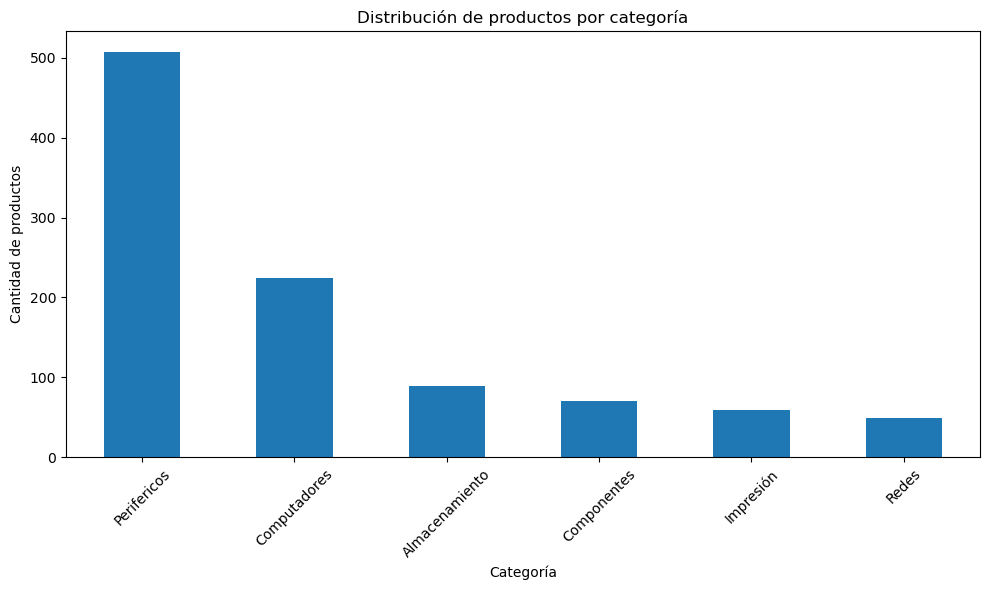

```python
plt.figure(figsize=(10, 6))

productos_categoria.plot(kind="bar")

plt.title("Distribución de productos por categoría")
plt.xlabel("Categoría")
plt.ylabel("Cantidad de productos")
plt.xticks(rotation=45)
plt.tight_layout()

plt.show()
```

```python
productos_frecuentes = df["Producto"].value_counts().head(10)

print("Top 10 productos más frecuentes:")
print(productos_frecuentes)
```

```
Top 10 productos más frecuentes:
Producto
Teclado          171
Mouse            170
Laptop           136
Monitor          129
PC Escritorio     89
Disco SSD         89
Memoria RAM       70
Impresora         59
Router            49
Cámara Web        38
Name: count, dtype: int64
```

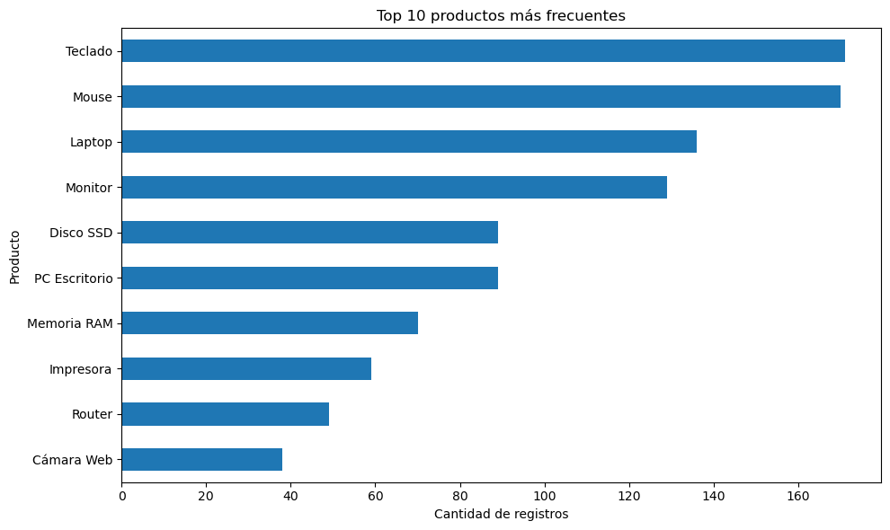

```python
plt.figure(figsize=(10, 6))

productos_frecuentes.sort_values().plot(kind="barh")

plt.title("Top 10 productos más frecuentes")
plt.xlabel("Cantidad de registros")
plt.ylabel("Producto")
plt.tight_layout()

plt.show()
```

```python
total_registros = len(df)
total_productos = df["Producto"].nunique()
total_categorias = df["Categoría"].nunique()
categoria_principal = df["Categoría"].value_counts().idxmax()
cantidad_categoria_principal = df["Categoría"].value_counts().max()

print("========== KPI DEL INVENTARIO ==========")
print(f"Total de registros: {total_registros}")
print(f"Productos diferentes: {total_productos}")
print(f"Categorías: {total_categorias}")
print(f"Categoría con mayor presencia: {categoria_principal}")
print(f"Cantidad en categoría principal: {cantidad_categoria_principal}")
```

```
========== KPI DEL INVENTARIO ==========
Total de registros: 1000
Productos diferentes: 10
Categorías: 6
Categoría con mayor presencia: Perifericos
Cantidad en categoría principal: 508
```

```python
resumen_categoria = (
    df["Categoría"]
    .value_counts()
    .rename_axis("Categoría")
    .reset_index(name="Cantidad")
)

resumen_categoria
```

|  | Categoría | Cantidad |
| --- | --- | --- |
| 0 | Perifericos | 508 |
| 1 | Computadores | 225 |
| 2 | Almacenamiento | 89 |
| 3 | Componentes | 70 |
| 4 | Impresión | 59 |
| 5 | Redes | 49 |

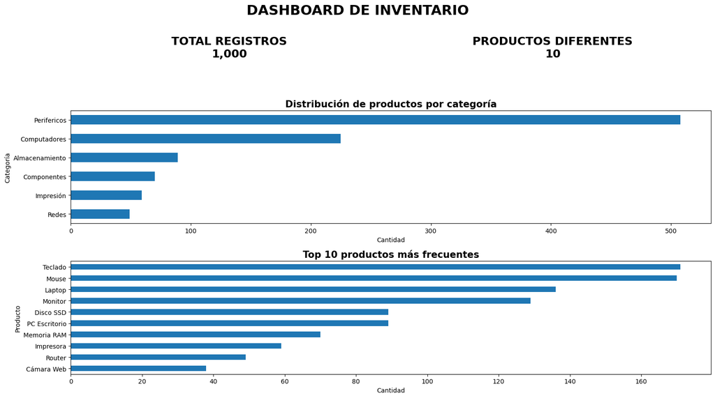

```python
import matplotlib.pyplot as plt

fig = plt.figure(figsize=(16, 9))
fig.suptitle(
    "DASHBOARD DE INVENTARIO",
    fontsize=22,
    fontweight="bold"
)
gs = fig.add_gridspec(3, 2, height_ratios=[0.8, 1.8, 1.8])

ax1 = fig.add_subplot(gs[0, 0])
ax1.axis("off")
ax1.text(
    0.5, 0.5,
    f"TOTAL REGISTROS\n{total_registros:,}",
    ha="center",
    va="center",
    fontsize=18,
    fontweight="bold"
)
ax2 = fig.add_subplot(gs[0, 1])
ax2.axis("off")
ax2.text(
    0.5, 0.5,
    f"PRODUCTOS DIFERENTES\n{total_productos}",
    ha="center",
    va="center",
    fontsize=18,
    fontweight="bold"
)

ax3 = fig.add_subplot(gs[1, :])

productos_categoria.sort_values().plot(
    kind="barh",
    ax=ax3
)
ax3.set_title(
    "Distribución de productos por categoría",
    fontsize=15,
    fontweight="bold"
)
ax3.set_xlabel("Cantidad")
ax3.set_ylabel("Categoría")

ax4 = fig.add_subplot(gs[2, :])

productos_frecuentes.sort_values().plot(
    kind="barh",
    ax=ax4
)
ax4.set_title(
    "Top 10 productos más frecuentes",
    fontsize=15,
    fontweight="bold"
)
ax4.set_xlabel("Cantidad")
ax4.set_ylabel("Producto")

plt.tight_layout()
plt.show()
```

```python
import os
os.makedirs("resultados", exist_ok=True)

fig.savefig(
    "resultados/dashboard_inventario.png",
    dpi=300,
    bbox_inches="tight"
)
fig.savefig(
    "resultados/dashboard_inventario.pdf",
    bbox_inches="tight"
)

print("==========================================")
print("DASHBOARD GUARDADO CORRECTAMENTE")
print("==========================================")
print("PNG: resultados/dashboard_inventario.png")
print("PDF: resultados/dashboard_inventario.pdf")
```

```
==========================================
DASHBOARD GUARDADO CORRECTAMENTE
==========================================
PNG: resultados/dashboard_inventario.png
PDF: resultados/dashboard_inventario.pdf
```

# 12. CONCLUSIONES Y HALLAZGOS

## Objetivo del análisis

El objetivo de este proyecto fue realizar un análisis exploratorio de un inventario de productos tecnológicos, utilizando Python y Pandas para identificar la distribución de los productos y categorías presentes en la base de datos.

## Principales resultados

- El conjunto de datos contiene **1.000 registros**.
- La información está organizada en tres variables: **ID, Producto y Categoría**.
- No se encontraron valores nulos en ninguna de las columnas.
- Se identificaron **6 categorías** de productos.
- La categoría con mayor presencia es **Periféricos**, con **508 registros**, equivalente al 50,8% del inventario.
- La categoría con menor presencia es **Redes**, con **49 registros**.
- Los productos con mayor frecuencia son **Teclado (171)** y **Mouse (170)**.
- El análisis permitió identificar los productos y categorías con mayor participación dentro del inventario.

## Hallazgos

Los resultados muestran una concentración importante del inventario en la categoría **Periféricos**. Esto indica que estos productos representan una parte significativa de la oferta analizada.

También se observa una alta frecuencia de productos como teclados y mouse, por lo que podrían requerir un seguimiento especial para mantener una disponibilidad adecuada.

## Recomendaciones

1. Realizar un seguimiento periódico de la categoría Periféricos.
2. Mantener un control especial sobre los productos con mayor frecuencia.
3. Revisar periódicamente las categorías con menor representación.
4. Actualizar la base de datos de inventario de manera periódica.
5. Utilizar el dashboard como herramienta de apoyo para el seguimiento del inventario.

## Conclusión

El análisis exploratorio permitió transformar una base de datos de inventario en información útil para comprender la composición de los productos y categorías. El uso de Python, Pandas y visualizaciones facilitó la identificación de patrones y permitió construir un dashboard que resume los principales resultados del inventario.